# DAIE CA4 Linear regression analysis

A Survey of Gamer Preferences Illustrated using GGPLOT

Shane Cunningham

January, 2023

```r
# Show available data sets

gamers <- read.csv("amalgamated_game_survey_250_2022.csv")
## attach(gamers) allows use of certain functions without typing data variable every time, eg. mean(age) instead of mean(gamers$age)
attach(gamers)
```

# **Statement of Assumptions**

## Summary of Data

```r
# sample(gamers)

summary(gamers)
```

```
##     gender               age        top_reason_gaming  gaming_platform
##  Length:250         Min.   :20.00   Length:250         Length:250
##  Class :character   1st Qu.:22.00   Class :character   Class :character
##  Mode  :character   Median :23.00   Mode  :character   Mode  :character
##                     Mean   :23.16
##                     3rd Qu.:24.00
##                     Max.   :33.00
##  favourite_game     avg_monthly_hrs_gaming avg_years_playing_games
##  Length:250         Min.   : 8.70          Min.   : 6.00
##  Class :character   1st Qu.:17.23          1st Qu.:10.00
##  Mode  :character   Median :19.80          Median :12.00
##                     Mean   :19.98          Mean   :11.78
##                     3rd Qu.:22.80          3rd Qu.:14.00
##                     Max.   :27.20          Max.   :17.00
##  avg_monthly_expenditure_dlc  ethnicity         play_roblox
##  Min.   :38.93               Length:250         Length:250
##  1st Qu.:47.47               Class :character   Class :character
##  Median :55.28               Mode  :character   Mode  :character
##  Mean   :55.48
##  3rd Qu.:63.48
##  Max.   :72.78
##   use_steam
##  Length:250
##  Class :character
##  Mode  :character
##
##
##
```

## Check Data for Normality

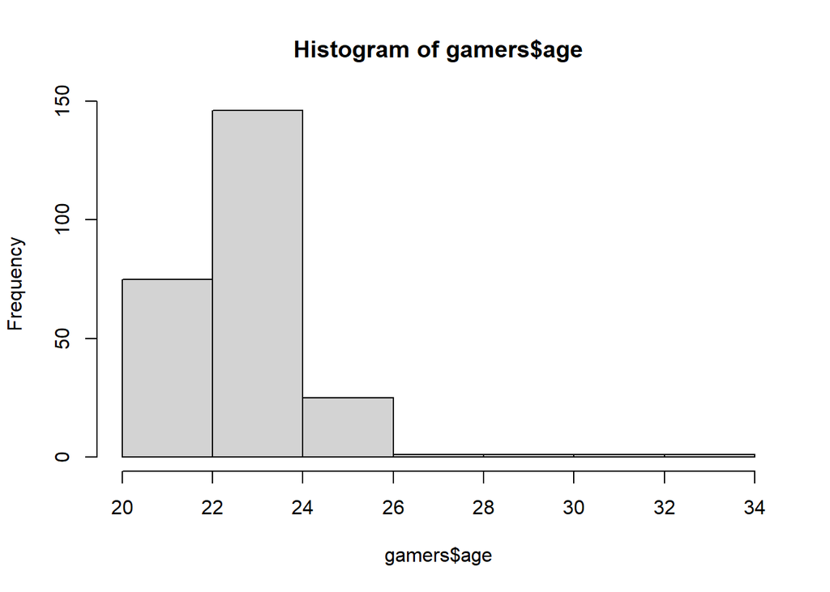

```r
hist(gamers$age)
```

The histogram for the variable “age” shows a right-skewed distribution

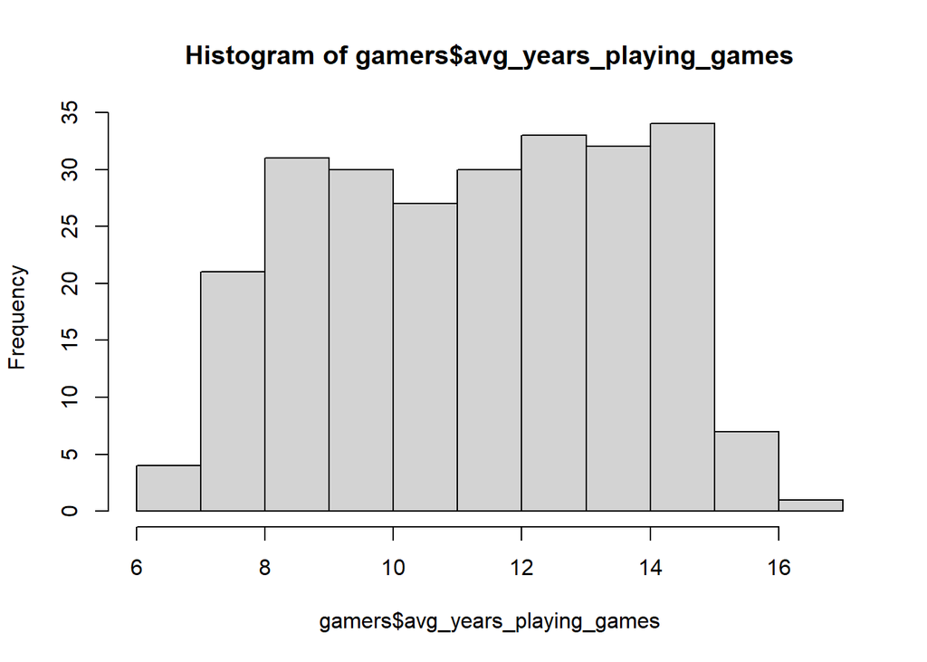

```r
hist(gamers$avg_years_playing_games)
```

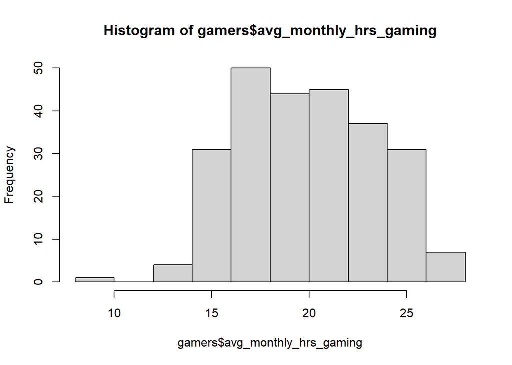

```r
hist(gamers$avg_monthly_hrs_gaming)
```

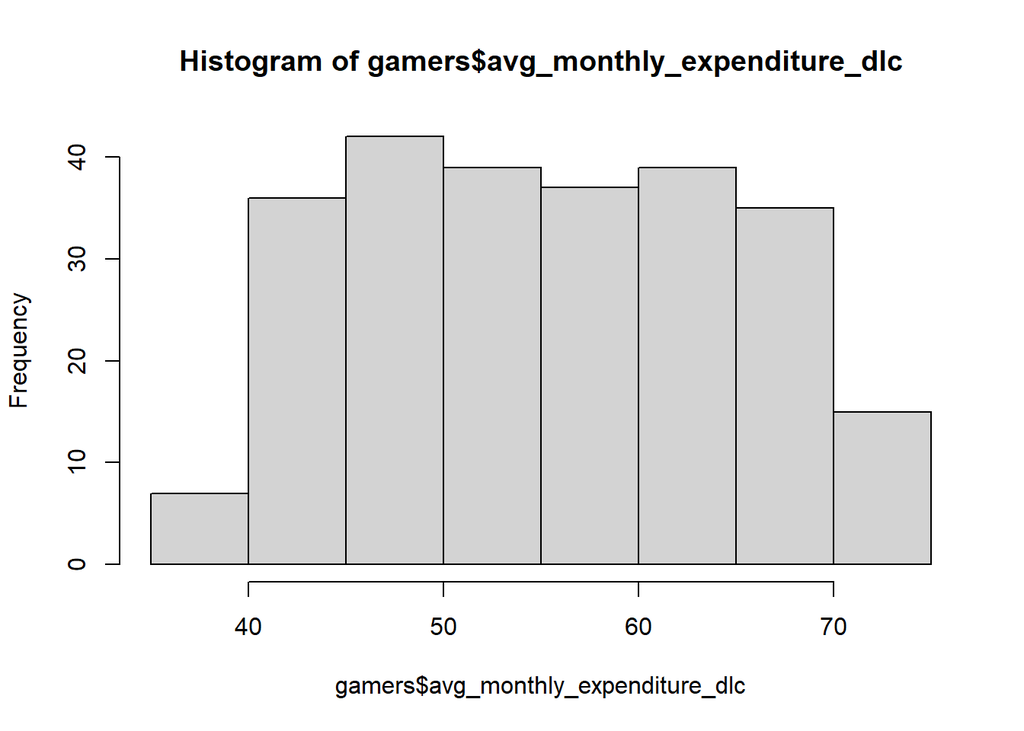

```r
hist(gamers$avg_monthly_expenditure_dlc)
```

#### **Check Data for Correlation Between Variables**

```r
cor(gamers$avg_monthly_expenditure_dlc, gamers$avg_monthly_hrs_gaming)
```

```
## [1] -0.007048283
```

The result show that there is very little correlation between the independent variables, meaning, There is little to no chance that the variables will effect each others results.

## Check Data for Linearity

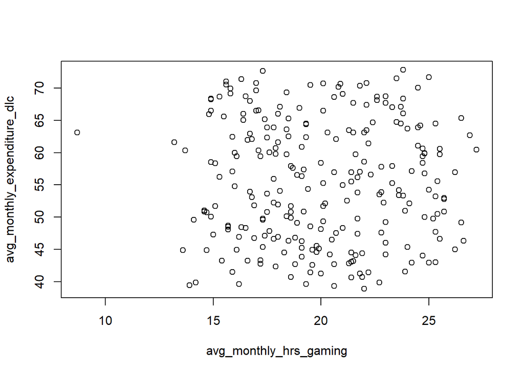

```r
plot(avg_monthly_expenditure_dlc ~ avg_monthly_hrs_gaming, data = gamers)
```

# **Testing of Assumptions**

### **Linear Regression Analysis**

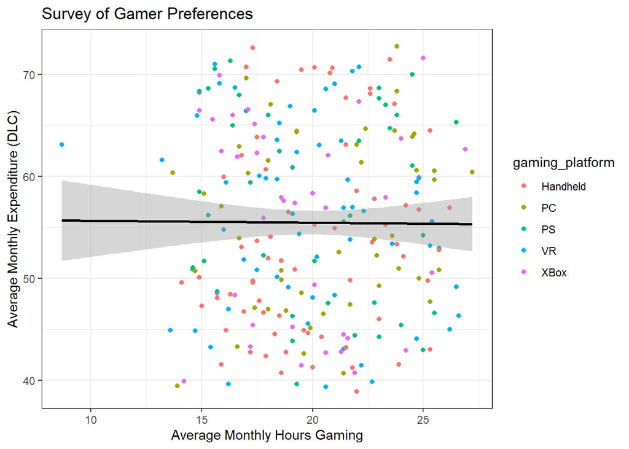

```r
gamers.graph <- ggplot(gamers, aes(x=avg_monthly_hrs_gaming, y=avg_monthly_expenditure_dlc, col=gaming_platform))+ geom_point() + geom_smooth(method="lm", col="black")

gamers.graph +
  theme_bw() +
  labs(title = "Survey of Gamer Preferences",
      x = "Average Monthly Hours Gaming",
      y = "Average Monthly Expenditure (DLC)")
```

### **Summary**

```r
avg_exp.avg_hrs_play.lm <- lm(avg_monthly_expenditure_dlc ~ avg_monthly_hrs_gaming, data = gamers)

summary(avg_exp.avg_hrs_play.lm)
```

```
##
## Call:
## lm(formula = avg_monthly_expenditure_dlc ~ avg_monthly_hrs_gaming,
##     data = gamers)
##
## Residuals:
##      Min       1Q   Median       3Q      Max
## -16.5118  -7.9872  -0.1674   8.0363  17.3721
##
## Coefficients:
##                        Estimate Std. Error t value Pr(>|t|)
## (Intercept)            55.85640    3.44352  16.221   <2e-16 ***
## avg_monthly_hrs_gaming -0.01885    0.16978  -0.111    0.912
## ---
## Signif. codes:  0 '***' 0.001 '**' 0.01 '*' 0.05 '.' 0.1 ' ' 1
##
## Residual standard error: 9.311 on 248 degrees of freedom
## Multiple R-squared:  4.968e-05,  Adjusted R-squared:  -0.003982
## F-statistic: 0.01232 on 1 and 248 DF,  p-value: 0.9117
```

The table above provides a summary of the residuals (The unexplained variance, model errors are calculated from the residuals), and the coefficients which shows the Intercept (Where the regression line intersects the Y-axis), the X-axis variable, the standard error, the t-value and the p-value.

# **Results**

The data from the survey of 250 participants show that the average monthly hours of gaming had very little correlation with the average monthly expenditure of downloaded content (p-value: 0.9117). The data are showing signs of constant variability and the outliers have no influence on the slope of the regression line. The lack of normal distribution in the data has effected the overall result. The Normal Q-Qplot shows a curved line, half of the line shows a good one to one relationship with the theoretical residuals.

### **Residual Plots**

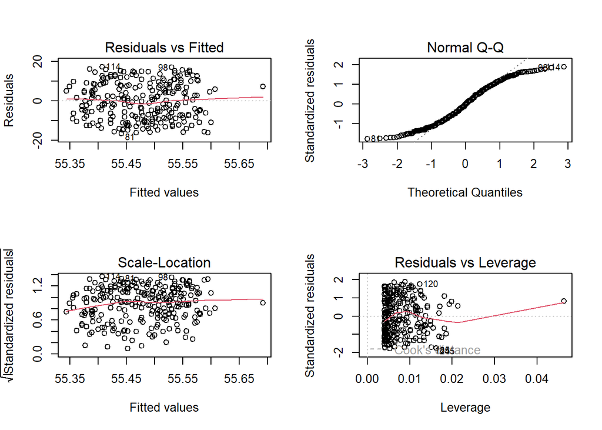

```r
par(mfrow=c(2,2))
plot(avg_exp.avg_hrs_play.lm)
```

```r
par(mfrow=c(1,1))
```

# **Bibliography**

‘8.1 - Line fitting, residuals, and correlation’ (no date). Available at: https://docs.google.com/presentation/d/1DqA5n0m53j2gZeqqn4Jog2B6JEzwXNOXtLPPPKY6ZH0 (Accessed: 19 January 2023).

‘8.2 - Fitting a line by least squares regression’ (no date). Available at: https://docs.google.com/presentation/d/1ABWqpgPhn3kphZ0iMPAIskb4JOrZnFJPhyPHctT-ptI (Accessed: 19 January 2023).

‘8.3 - Types of outliers in linear regression’ (no date). Available at: https://docs.google.com/presentation/d/1PBKxvXhjl9M1bTcFT2bSzMRtNtWarUtdipd5EeTJzHk (Accessed: 19 January 2023).

‘8.4 - Inference for linear regression’ (no date). Available at: https://docs.google.com/presentation/d/1yR49VoXAbmblIACHaWVDUpX6ROLLXYt9gsnoNV5USuI (Accessed: 19 January 2023).

Bevans, R. (2020a) Linear Regression in R | A Step-by-Step Guide & Examples, Scribbr. Available at: https://www.scribbr.com/statistics/linear-regression-in-r/ (Accessed: 19 January 2023).

Bevans, R. (2020b) Simple Linear Regression | An Easy Introduction & Examples, Scribbr. Available at: https://www.scribbr.com/statistics/simple-linear-regression/ (Accessed: 19 January 2023).

Bhandari, P. (2021) Correlation vs. Causation | Difference, Designs & Examples, Scribbr. Available at: https://www.scribbr.com/methodology/correlation-vs-causation/ (Accessed: 20 January 2023).

Line Fitting, Residuals, and Correlation (2014). Available at: https://www.youtube.com/watch?v=mPvtZhdPBhQ (Accessed: 19 January 2023).